# Rapport glycémie 100

CHAUVEAU Alice

2024-02-13

# Récupération des données et séparation

# Avant/Pendant/Après courses

## Par date

#Mediane

#Trouver le participant median

#Creation Dataframe participant median ici le 23

#Quantile 0.25

#Quantile 0.75

#Mise en forme données

#Création dataframe final pour tracer le graphique avec les données médianes générales, données q1, données q3 et données du participant médian

#Graphique médiane et quantiles du glucose par jour avant, pendant et après la course 100km

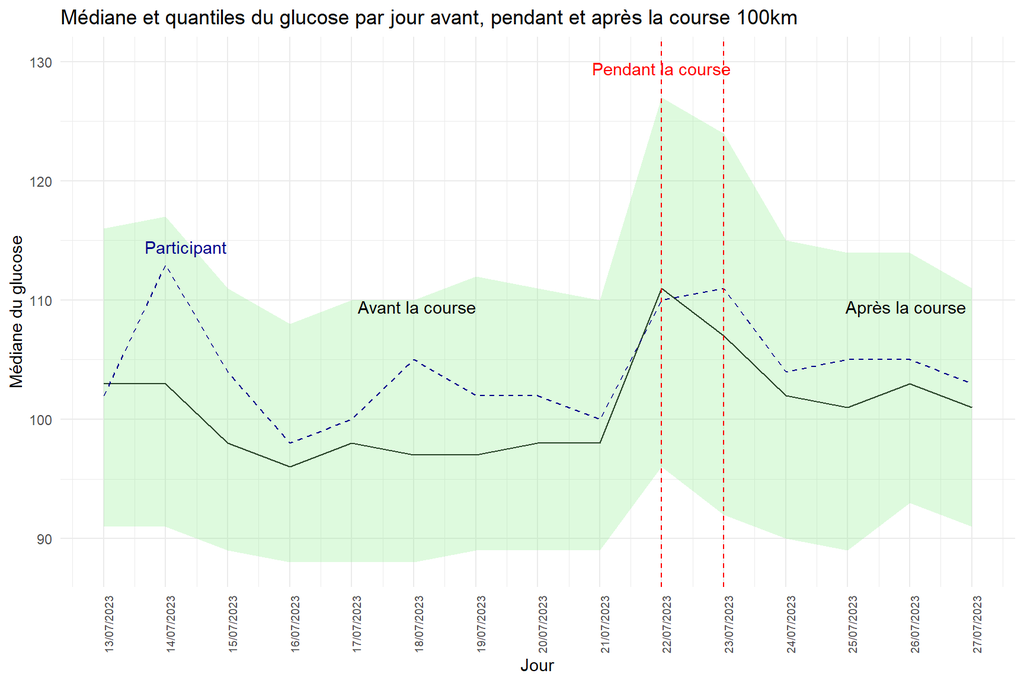

####################################################################################### ## Par heure #Mediane

#Trouver le participant median

#Quantile 0.25

#Quantile 0.75

#Creation dataframe participant median

#Mise en forme données

#Création dataframe final pour tracer le graphique avec les données médianes générales, données q1, données q3 et données du participant médian

#Graphique médiane et quantiles du glucose par heure avant, pendant et après la course 100km

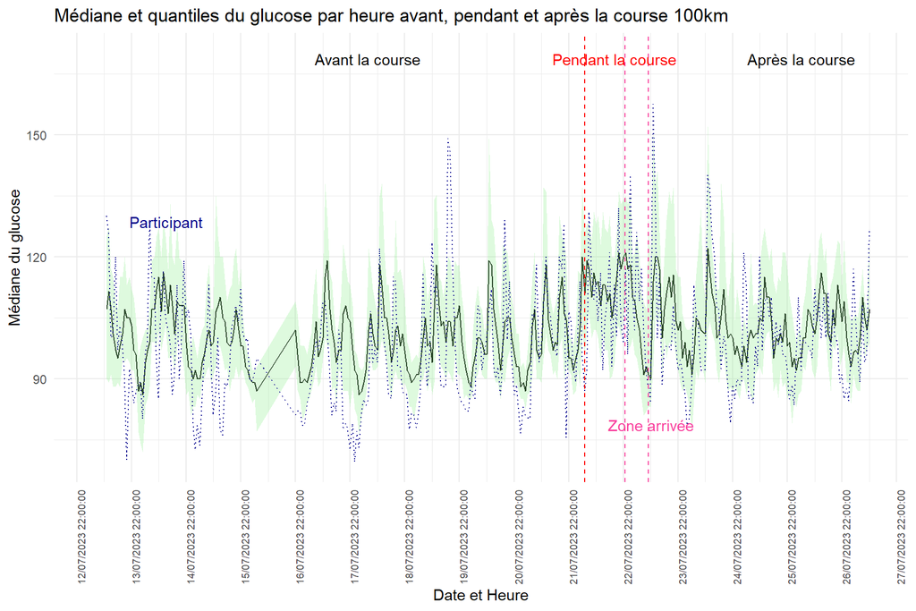

################################################################ # Pendant la course #Filtrer données de glycémie de la course entre début et fin de la course

##Par heure #Mediane

#Trouver le participant median

#Quantile 0.25

#Quantile 0.75

#Creation dataframe participant median

#Mise en forme données

#Création dataframe final pour tracer le graphique avec les données médianes générales, données q1, données q3 et données du participant médian

#Graphique médiane et quantiles du glucose par heure pendant la course 100 km

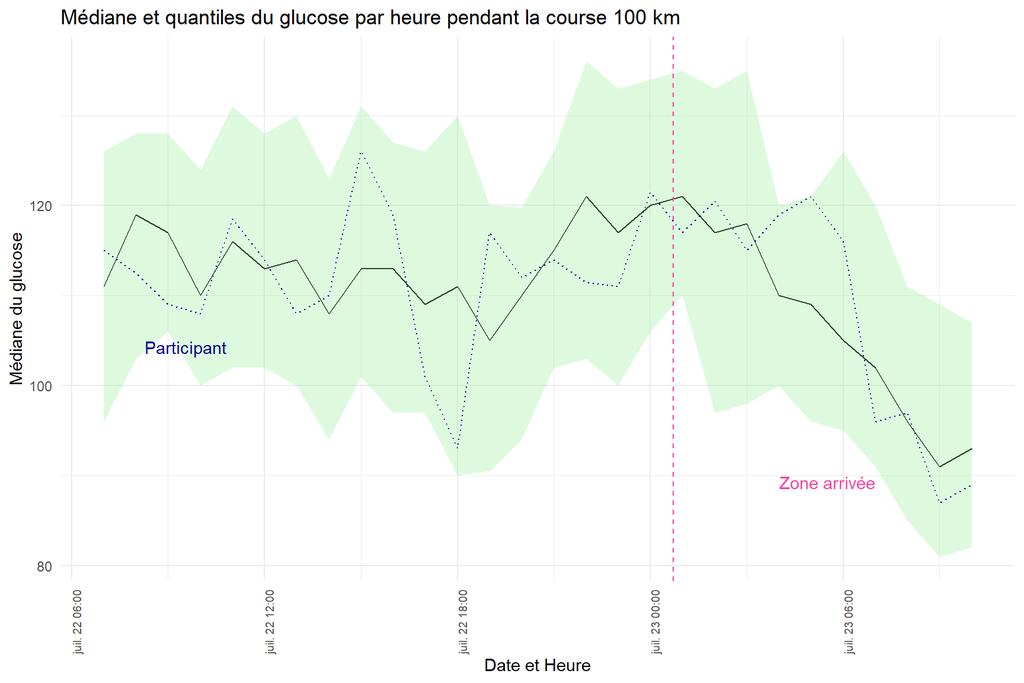

##Par minutes pendant la course #Création dataframe

#Graphique médiane et quantiles du glucose par minutes pendant la course 100 km

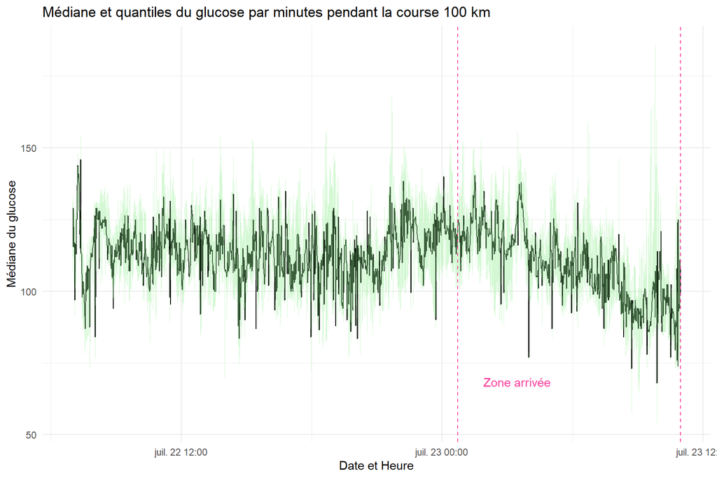

##Graphique de la glycémie des coureurs pendant la course #Abandons #Coureur 37

#Coureur 4

#Coureur 23

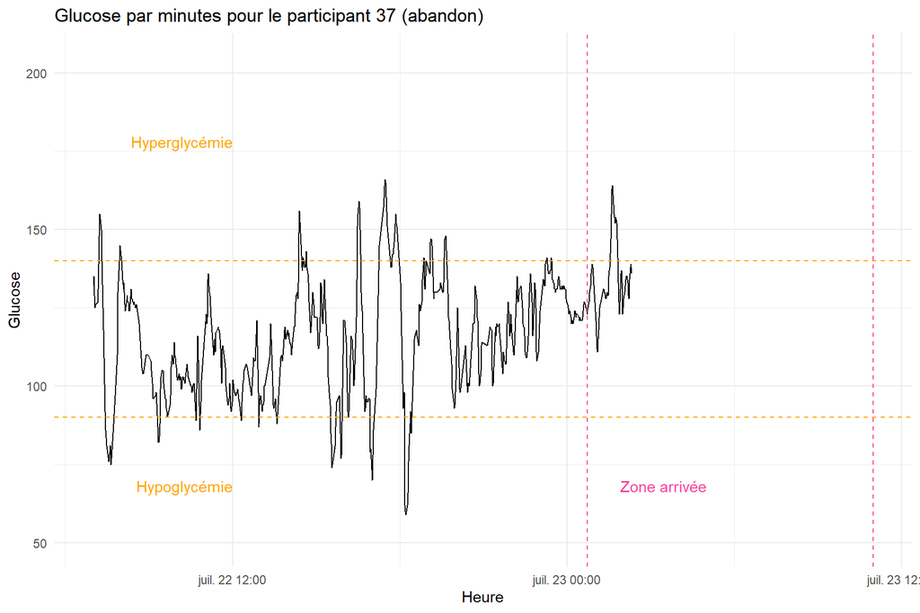

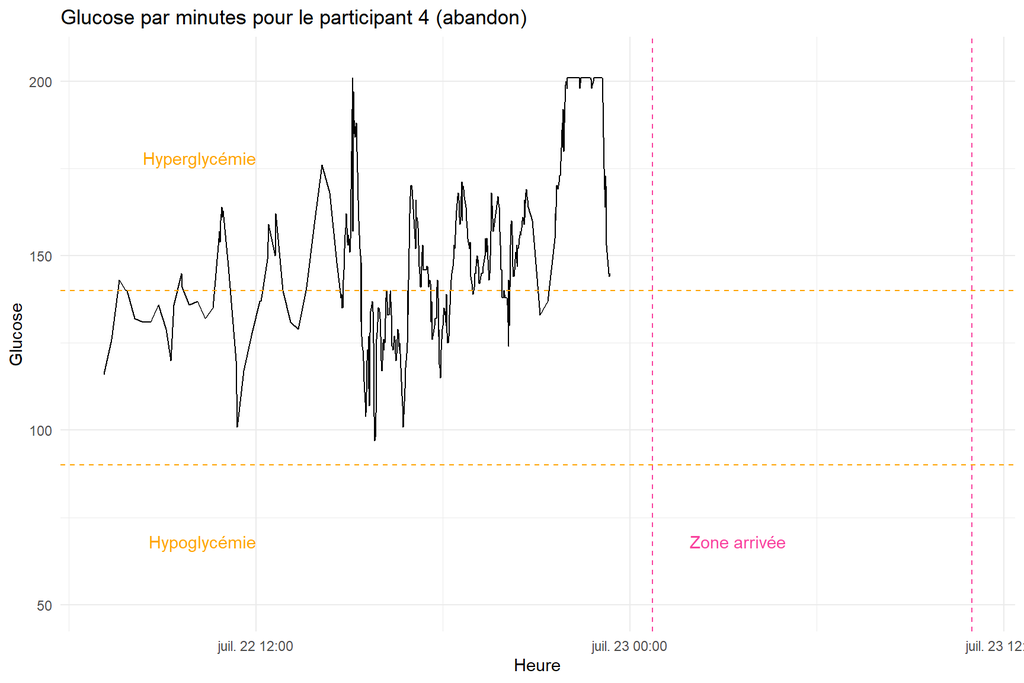

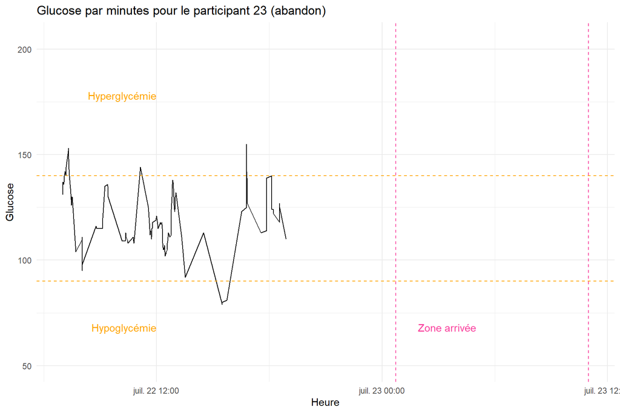

#Finisher #Coureur 13

#Coureur 29

#Coureur 18

#Coureur 6

#Coureur 19

#Coureur 11

#Coureur 38

#Coureur 32

#Coureur 21

#Coureur 31

#Coureur 10

#Coureur 26

#Coureur 27

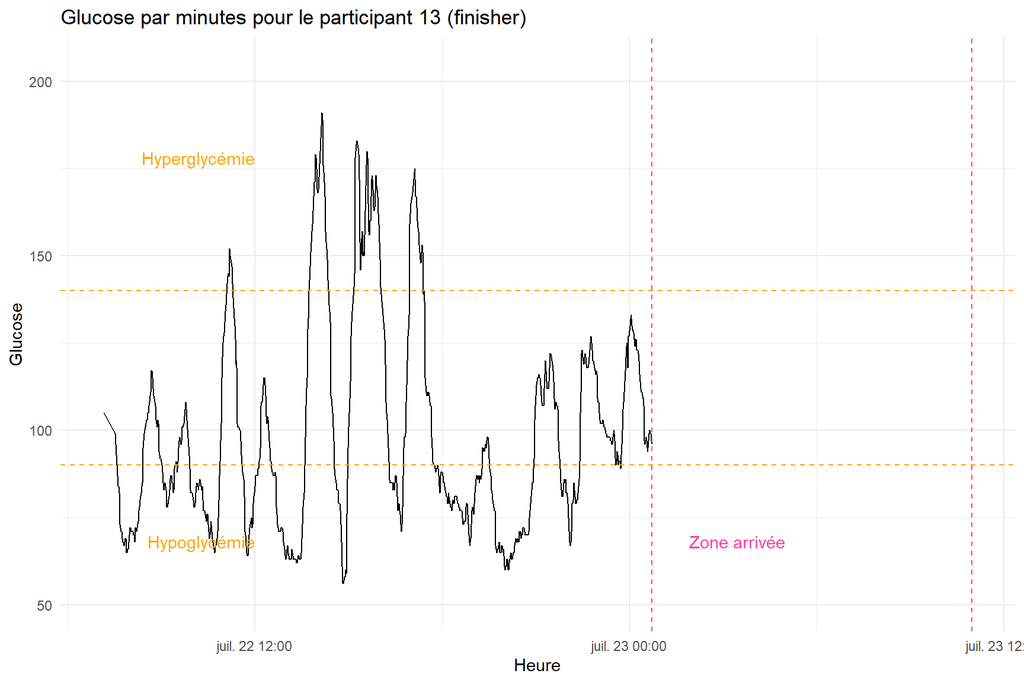

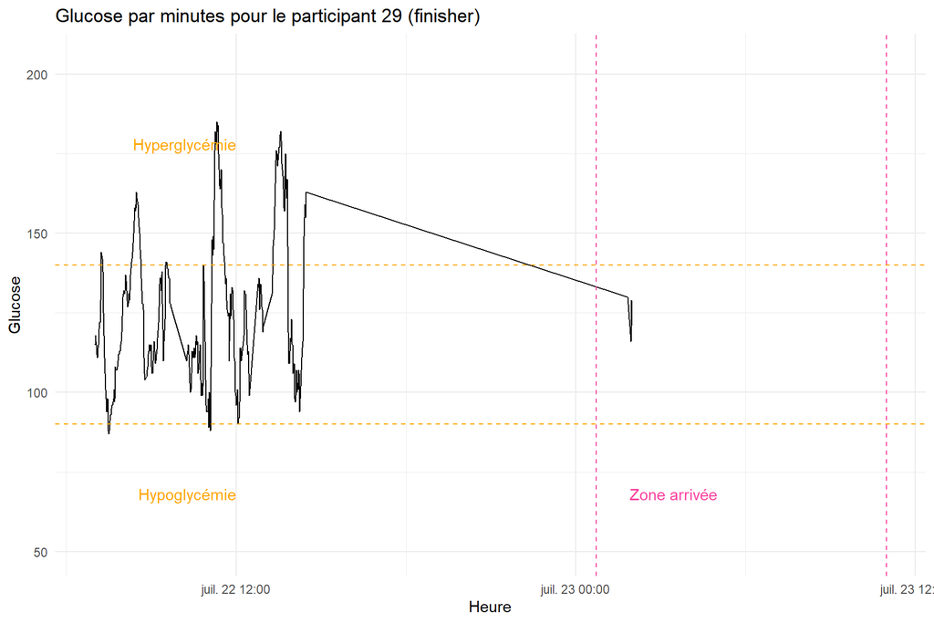

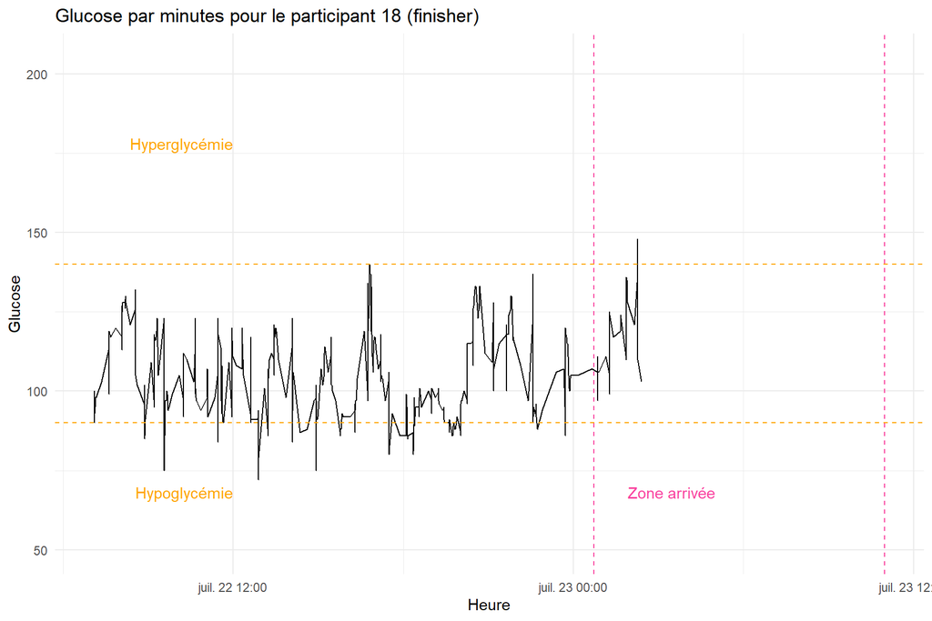

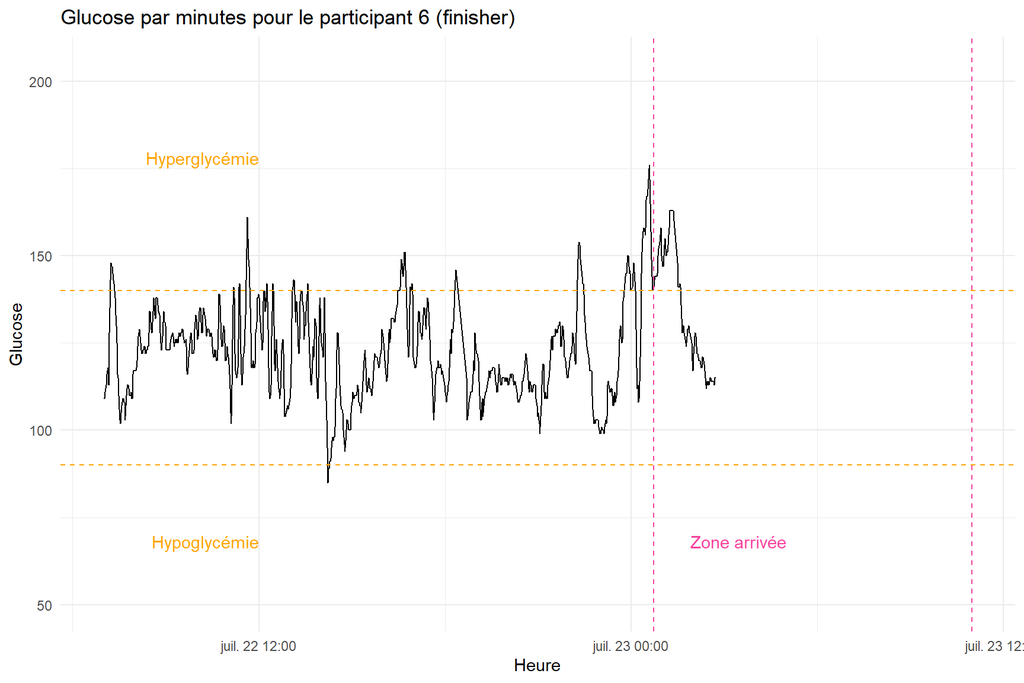

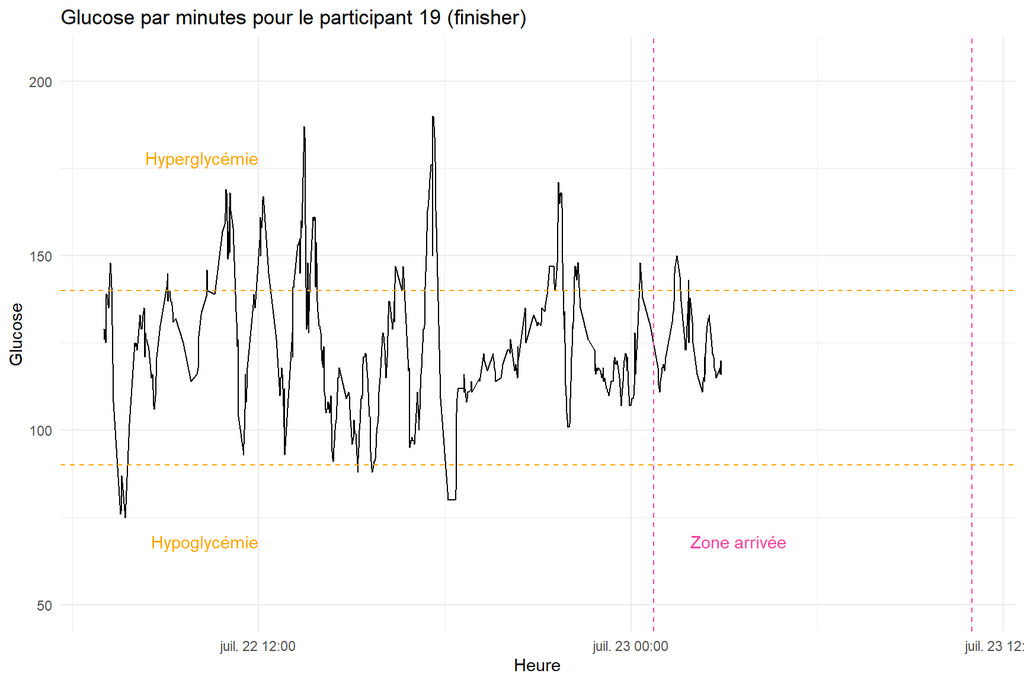

[figure not shown]

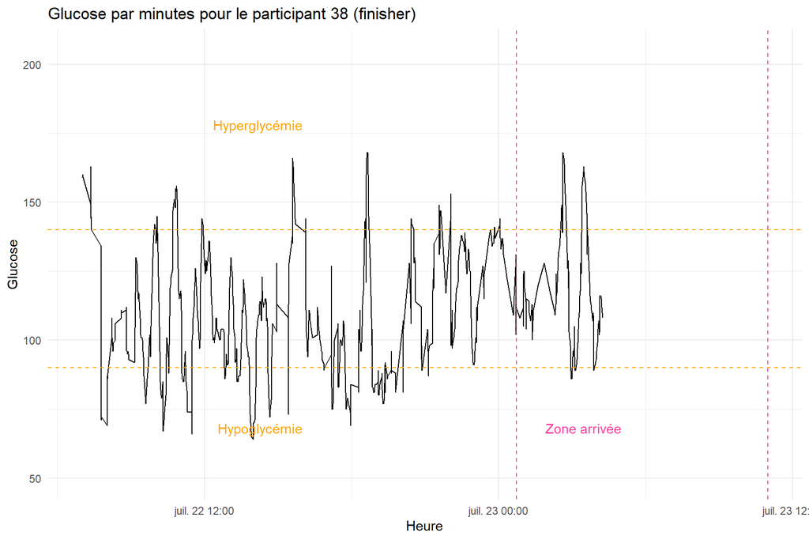

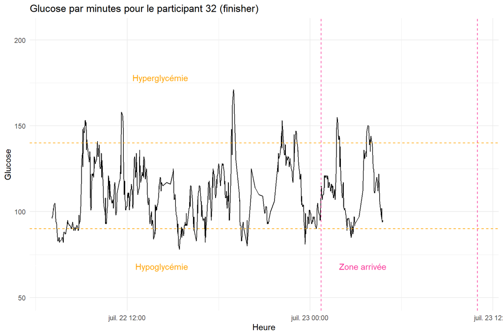

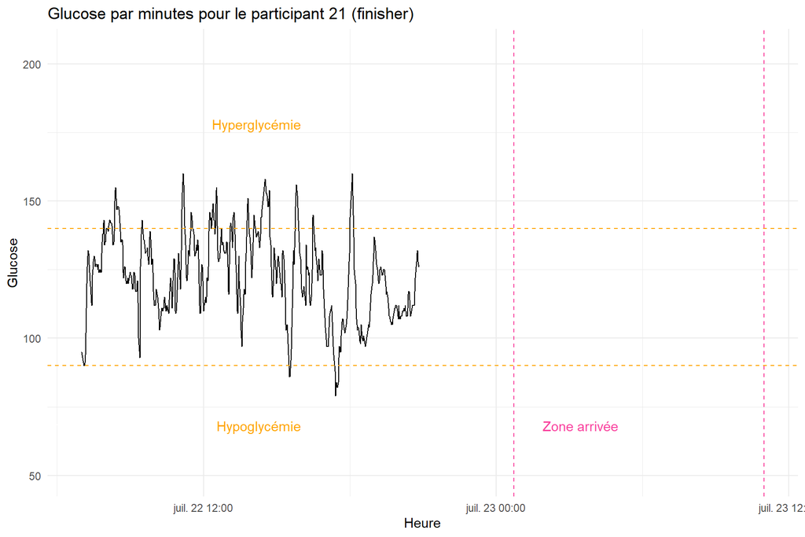

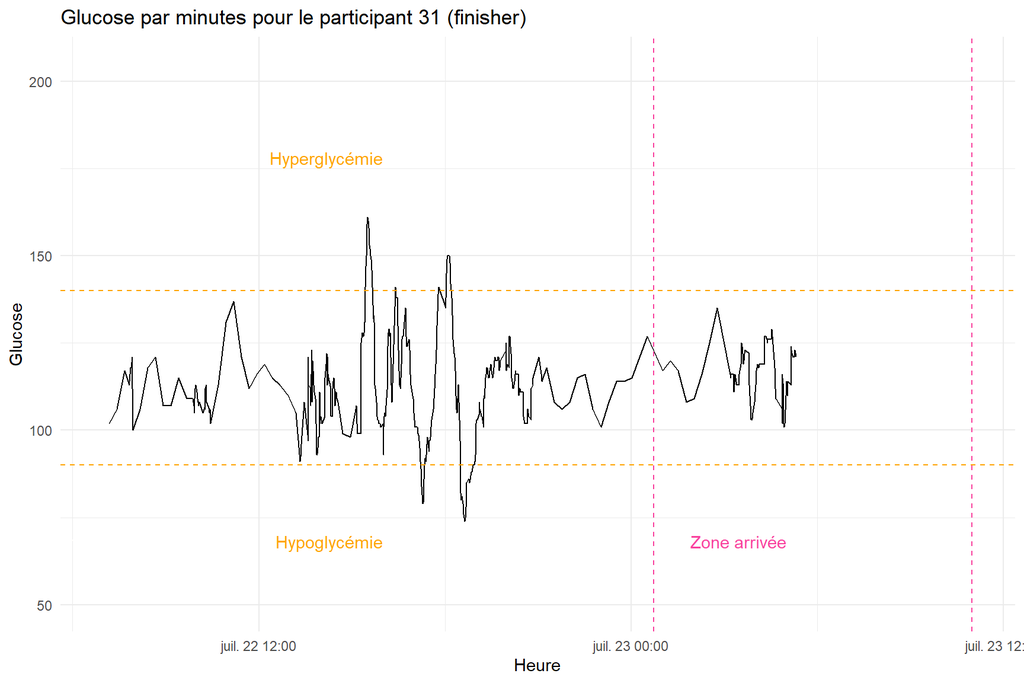

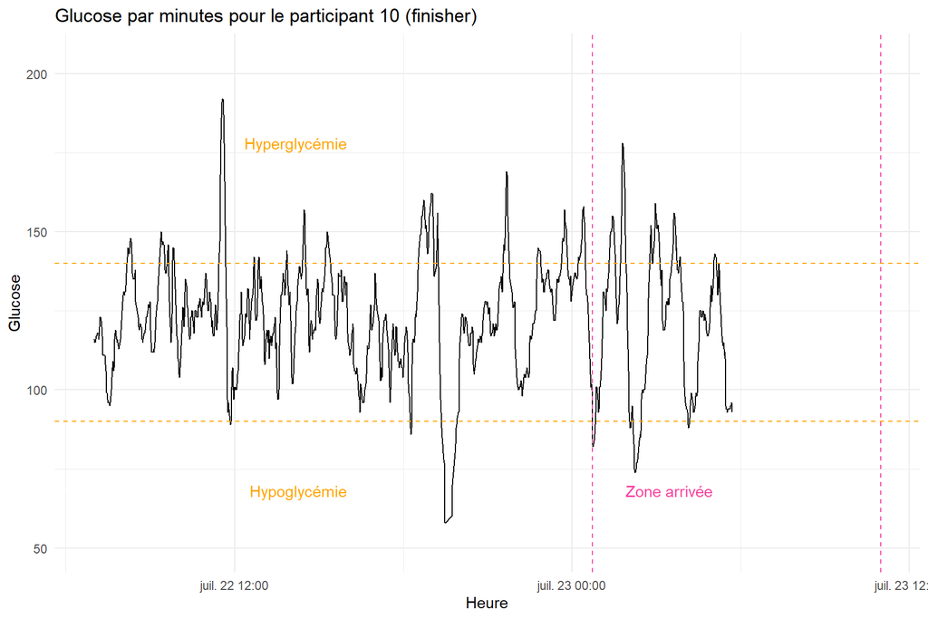

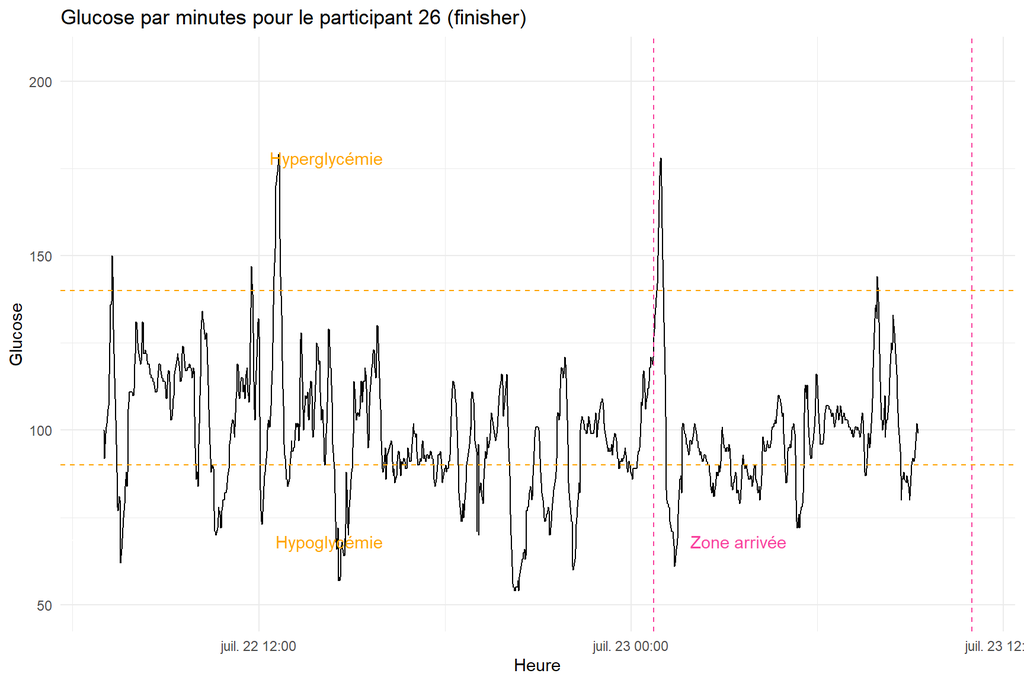

[1 more figures not shown]

################################################################################# #Graphique par km #Importation des données

#Mediane

#Trouver le participant median

#Creation dataframe participant median

#Quantile 0.25

#Quantile 0.75

#mise en forme des données

#Création dataframe final pour tracer le graphique avec les données médianes générales, données q1, données q3 et données du participant médian

#Graphique

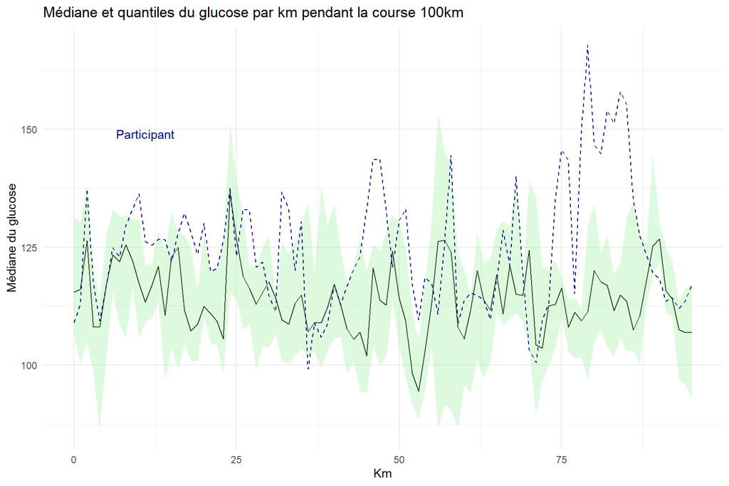